# Holt’s Method in R

Week 12 R-lab:Dealing with trends and no seasonality  
Zhaohu(Jonathan) Fan

07/29/2021

# Forecasting Method(s)

- 1. Define Goal
- 2. Get Data
- 3. Explore & Visualize Series
- 4. Pre-Process Data
- 5. Partition Series
- 6. $\color{red}{\text{Apply Forecasting Method(s): Holt’s Method}}$
- 7. Evaluate & Compare Performance
- 8. Implement Forecasts/System

# Main Ideas

- Holt’s method can capture a trend component
- Trend can be additive

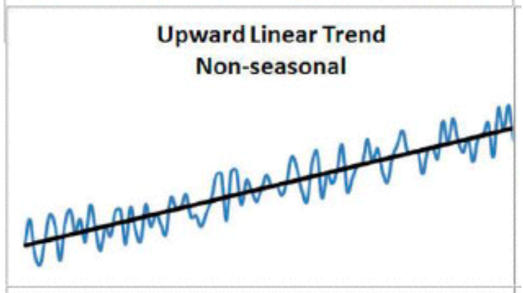

# Main Ideas (cont’d)

- Trend can be multiplicative

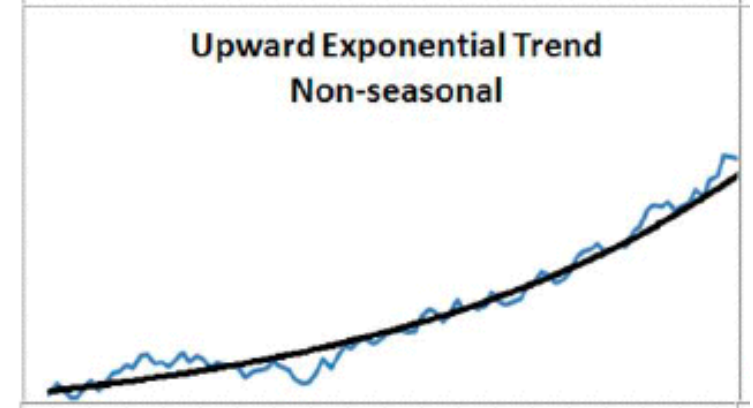

# The (Additive) Equation

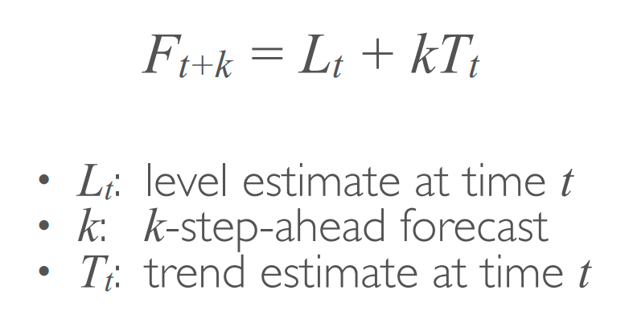

# The Updating Equations

- Level at time t is a weighted average of the actual value at time t and the level in the previous period, adjusted for trend.

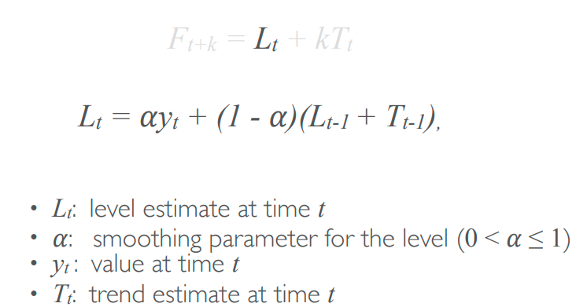

# The Updating Equations (cont’d)

- Trend at time t is a weighted average of the trend in the previous period and the more recent information on the change in level.

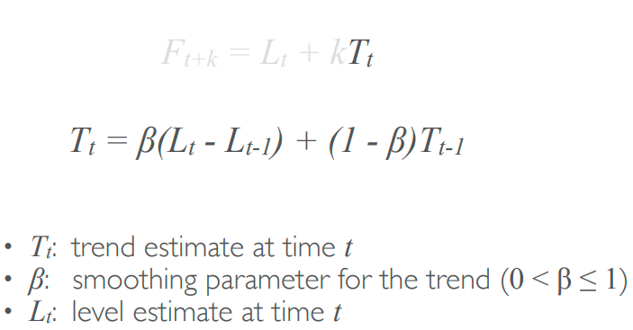

# Additive VS Multiplicative Trend

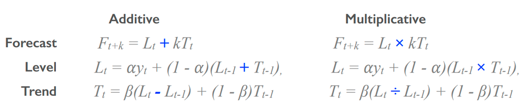

# Technical Notes (Choosing $\alpha$ and $\beta$)

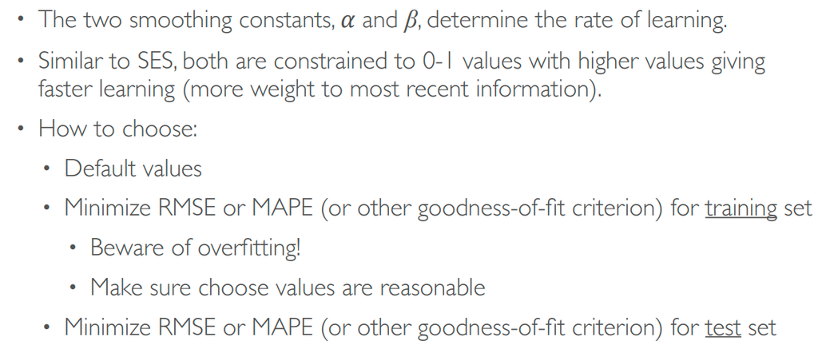

# Data Example (Let’s practice!)

- Our goal is to use the data set ‘books.csv’ to forecast the next four day’s sales for paperback books.
- Step 1: Load packages used

```r
library(tidyverse)
library(fpp2)
library(readxl)
```

- Step 2: Import and convert paperback to time series object

```r
setwd("C:/Users/fanzh/OneDrive - University of Cincinnati/UC_couse/000_Teaching_4090_SS21/Labs/Week13")
books <- read_csv("books.csv")
head(books,5)
```

```
## # A tibble: 5 x 3
##     Day Paperback Hardcover
##   <dbl>     <dbl>     <dbl>
## 1     1       199       139
## 2     2       172       128
## 3     3       111       172
## 4     4       209       139
## 5     5       161       191
```

```r
paper.ts <- ts(books["Paperback"], start = 1, frequency = 1)
```

Note: Use of “[ ]” for subsetting and indexing

# Data Example (cont’d)

- Step 3: Plot the paperback series

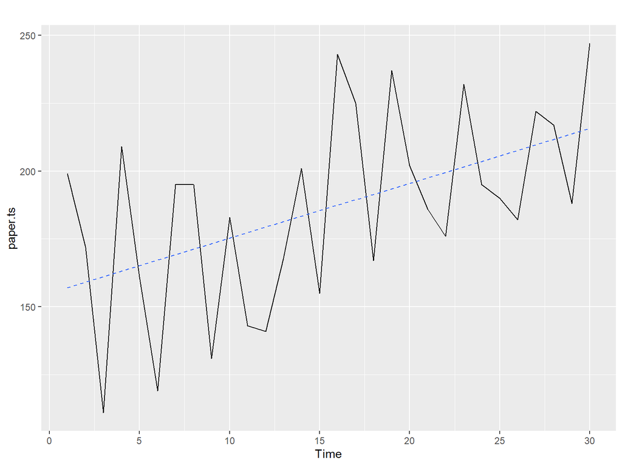

```r
autoplot(paper.ts) + geom_smooth(method = "lm", linetype = "dashed", se = FALSE, size = .5)
```

- The data has upward trend, which is probably linear.
- The data has cyclic structure, although seasonality is not present.

# Data Example (cont’d)

- Step 4: Partition the data so that the last four observations are used for your test data

```r
library(forecast)
# partition
paper_train <- subset(paper.ts,end = length(paper.ts)- 4)
paper_test <- subset(paper.ts,start = length(paper.ts) - 3)

paper_train
```

```
## Time Series:
## Start = 1
## End = 26
## Frequency = 1
##  [1] 199 172 111 209 161 119 195 195 131 183 143 141 168 201 155 243 225 167 237
## [20] 202 186 176 232 195 190 182
```

```r
paper_test
```

```
## Time Series:
## Start = 27
## End = 30
## Frequency = 1
## [1] 222 217 188 247
```

# Data Example (cont’d)

- Step 5: Use Holt’s exponential smoothing and let the `R` select the optimal $\alpha$ and $\beta$.

Now perform an SES model on the same data with $\alpha$= .22. Compare the forecast accuracy

```r
holt.1 <- holt(paper_train, h = 4)
holt.1$model$par
```

```
##        alpha         beta            l            b
## 1.272551e-04 1.272546e-04 1.709718e+02 1.073746e+00
```

```r
ses.1 <- ses(paper_train, alpha = 0.22, h = 4)
accuracy(ses.1, paper_test)
```

```
##                     ME     RMSE      MAE       MPE     MAPE      MASE
## Training set  4.085371 34.38411 28.72038 -1.299844 16.60708 0.7060073
## Test set     24.654625 32.35893 27.57731 10.440862 11.99548 0.6779084
##                    ACF1 Theil's U
## Training set -0.2300195        NA
## Test set     -0.4716847  0.885096
```

```r
accuracy(holt.1, paper_test)
```

```
##                     ME     RMSE      MAE       MPE     MAPE      MASE
## Training set -3.875031 31.94914 26.36988 -5.838267 16.06684 0.6482272
## Test set     17.265080 26.95439 24.14777  7.035506 10.69651 0.5936030
##                    ACF1 Theil's U
## Training set -0.1460121        NA
## Test set     -0.4725323 0.7436385
```

# Data Example (cont’d)

- Step 6:Now that we know a Holt’s model outperforms an SES model on this data, try to identify the optimal Holt’s model by explore different values of $\beta$ (.01, .02, .03, etc).
- Record the test prediction RMSE for the forecasts. How do $\beta$ values effect the forecasts?

```r
holt.2 <- holt(paper_train, beta = .0001, h = 4)
holt.3 <- holt(paper_train, beta = .01, h = 4)
holt.4 <- holt(paper_train, beta = .02, h = 4)
holt.5 <- holt(paper_train, beta = .03, h = 4)
accuracy(holt.2, paper_test)
```

```
##                        ME     RMSE      MAE       MPE      MAPE      MASE
## Training set  0.001910305 31.24973 27.14295 -3.342804 15.984833 0.6672309
## Test set     10.361917138 23.02431 20.87563  3.852046  9.444449 0.5131670
##                    ACF1 Theil's U
## Training set -0.2001945        NA
## Test set     -0.4704006 0.6434603
```

```r
accuracy(holt.3, paper_test)
```

```
##                     ME     RMSE      MAE       MPE      MAPE      MASE
## Training set 0.2791253 31.94753 27.87179 -3.200323 16.330859 0.6851472
## Test set     7.2539401 21.77224 19.37082  2.417735  8.862881 0.4761754
##                    ACF1 Theil's U
## Training set -0.1774839        NA
## Test set     -0.4694223 0.6123366
```

```r
accuracy(holt.4, paper_test)
```

```
##                     ME     RMSE      MAE        MPE      MAPE      MASE
## Training set 0.6368662 32.72399 28.67390 -2.9929158 16.691485 0.7048649
## Test set     3.6814208 20.83938 17.61115  0.7680568  8.177487 0.4329191
##                    ACF1 Theil's U
## Training set -0.1523989        NA
## Test set     -0.4688218 0.5893246
```

```r
accuracy(holt.5, paper_test)
```

```
##                     ME     RMSE      MAE       MPE      MAPE      MASE
## Training set 0.7806983 33.56110 29.54467 -2.872103 17.083170 0.7262702
## Test set     0.2235567 20.54383 16.00000 -0.831120  7.548775 0.3933137
##                    ACF1 Theil's U
## Training set -0.1261325        NA
## Test set     -0.4698821 0.5826467
```

# Data Example (cont’d)

```r
beta <- seq(0.001, 0.499, 0.001)
```

Initialization of variable RMSE with a single value NA.

```r
RMSE <- NA
```

Iterate through all values of vector beta and assess prediction accuracy

```r
library(ggplot2)
library(tidyverse)
for(i in seq_along(beta)) {
 fcast <- holt(paper_train, beta = beta[i], h = 4)
 RMSE[i] <- accuracy(fcast, paper_test)[2, 2]
}
# turn our RMSE values for beta .001-.49 into a data frame
error <- data_frame(beta, RMSE)


minimum <- filter(error, RMSE == min(RMSE))
minimum
```

```
## # A tibble: 1 x 2
##    beta  RMSE
##   <dbl> <dbl>
## 1 0.029  20.5
```

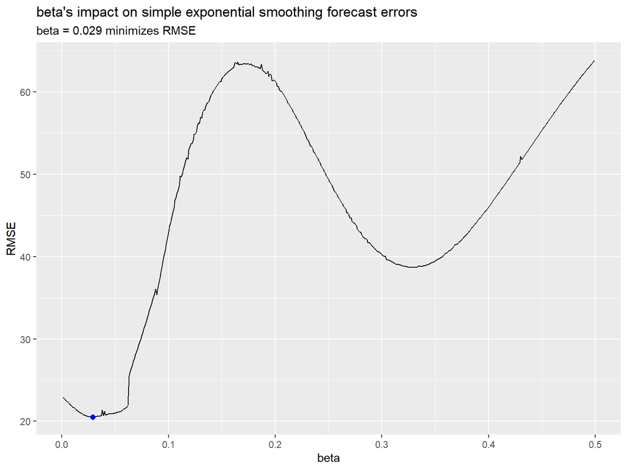

```r
# plot RMSE values for beta .001-.49
ggplot(error, aes(beta, RMSE)) +
 geom_line() +
 geom_point(data = minimum, color = "blue", size = 2) +
 ggtitle("beta's impact on simple exponential smoothing forecast errors",
 subtitle = "beta = 0.029 minimizes RMSE")
```

# Data Example (cont’d)

- Step 8 : Let’s assess the forecast accuracy of this optimal model

```r
holt.opt <- holt(paper_train, beta = 0.029, h = 4)
accuracy(holt.opt, paper_test)
```

```
##                     ME     RMSE      MAE        MPE      MAPE      MASE
## Training set 0.8707969 33.47257 29.43919 -2.8301255 17.026283 0.7236772
## Test set     0.3604158 20.53232 16.00000 -0.7672094  7.546224 0.3933137
##                    ACF1 Theil's U
## Training set -0.1284364        NA
## Test set     -0.4694515 0.5818414
```

# Data Example (cont’d)

- Step 9 : Using the optimal Holt model we found, provide the point estimate and confidence intervals for the next 4 periods sales.

```r
holt.opt
```

```
##    Point Forecast    Lo 80    Hi 80    Lo 95    Hi 95
## 27       215.1846 168.5508 261.8184 143.8644 286.5048
## 28       217.1546 170.4425 263.8667 145.7145 288.5946
## 29       219.1246 172.2366 266.0126 147.4156 290.8336
## 30       221.0946 173.8955 268.2936 148.9099 293.2792
```

Provide a plot as well.

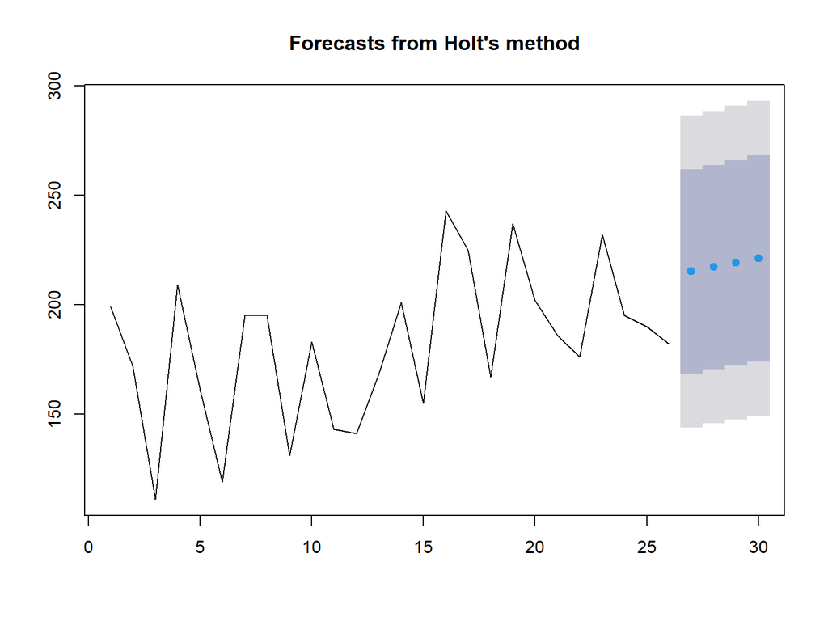

```r
plot(holt.opt)
```